# Skalowanie Wielowymiarowe

Grabowski Pawel

**Najpierw przykady potem to samo zrobione dla zasymulowanych danych**

### Idea:

Jedna z wad metody PCA jest mozliwosc uzywania jedynie zmiennych ilosciowych, kolejnym koniecznosc posiadania pelnych danych z doswiadczenia (nie da sie uzyc PCA jesli mamy wylacznie informacje o podobienstwie obiektów). Skalowanie wielowymiarowe pozbawione jest tych wad. Jest to metoda redukcji wymiarowosci bazujaca na macierzy niepodobienstwa pomiedzy obiektami. Celem tej metody jest wyznaczenie wspólrzednych obserwacji w nowym ukladzie, w taki sposób aby odleglosci pomiedzy obiektami w tym nowym ukladzie wspólrzednych byly maksymalnie podobne do oryginalnych odleglosci pomiedzy obserwacjami.

Funkcje oceniajaca rozbieznosc pomiedzy danymi niepodobienstwami, a obliczonymi w nowej przestrzeni danych nazywamy funkcja stresu. Naszym celem jest oczywiscie jej minimalizacja. Uzyskana wartosc funkcji stresu moze sluzyc za miare jakosci uzyskanego odwzorowania.

### Rodzaje skalowania:

**Metryczne**– minimalizujemy sume modulów (kwadratów) róznic pomiedzy oryginalnymi odleglosciami oraz odleglosciami w nowo powstalym ukladzie wspólrzednych. Zakladamy, ze dysponujemy jedynie cechami ilosciowymi. Jesli dysponujemy oryginalnym zbiorem danych, a nie macierza niepodobienstw, skalowanie wielowymiarowe jest tozsame z analiza skladowych glównych (na macierzy kowariancji) i nazywa sie klasycznym skalowaniem wielowymiarowym. Skalowanie metryczne uzywamy gdy mamy przekonanie, ze konkretna odleglosc w sposób wlasciwy reprezentuje odleglosci pomiedzy obiektami.

**Niemetryczne** – poszukujemy sie optymalnego porzadku pomiedzy odleglosciami, przy czym nie ma znaczenia sama wartosc odleglosci, jedynie ich porzadek. Zakladamy, ze dane sa mieszanina danych jakosciowych i ilosciowych. W przypadku danych ilosciowych musi istniec pomiedzy nimi pewien porzadek. W przeciwienstwie do klasycznego skalowania nie istnieje analityczne rozwiazanie tego zagadnienia. Co gorsza procedura poszukiwania rozwiazania jest iteracyjna i wymaga poczatkowej konfiguracji punktów (najczesciej przyjmuje sie za nie rozwiazanie uzyskane ze skalowania metrycznego). Ta metoda jest czesciej uzywana w praktyce.

Do przeprowadzania skalowania metrycznego wykorzystywana jest funkcja *cmdscale*. Jesli nie dysponujemy odleglosciami miedzy obiektami, mozemy je z latwoscia wyliczyc korzystajac z funkcji *dist*, która moze wyliczyc wiele typów odleglosci (domyslnie liczy odleglosc euklidesowa).

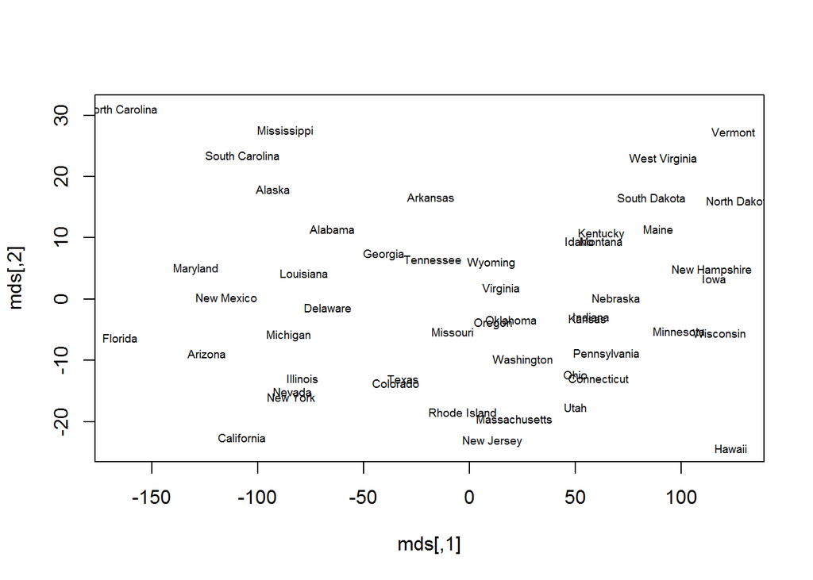

```r
mds = cmdscale(dist(USArrests))
plot(mds, type = 'n')
text(mds, rownames(mds), cex = 0.6)
```

Jezeli jednak w danych znajduja sie nie tylko zmienne ilosciowe to *dist* nie da sobie z nimi rady. W takiej sytuacji nalezy wykorzystac funkcje *daisy* z pakietu **cluster**, która w przypadku danych ilosciowych liczy odleglosc euklidesowa.natomiast w przypadku wykrycia danych jakosciowych wyznacza wspólczynnik podobienstwa Gowera.

Niemetryczne skalowanie wielowymiarowe zostalo zaimplementowane w pakiecie **MASS**. Znajduja sie tam dwie funkcje *sammon* oraz *isoMDS*, które realizuja dwa rózne algorytmy skalowania niemetrycznego

```r
library(MASS)
mds1 = sammon(dist(USArrests))
```

```
## Initial stress        : 0.00126
## stress after  10 iters: 0.00071, magic = 0.500
## stress after  20 iters: 0.00070, magic = 0.500
```

```r
mds2 = isoMDS(dist(USArrests))
```

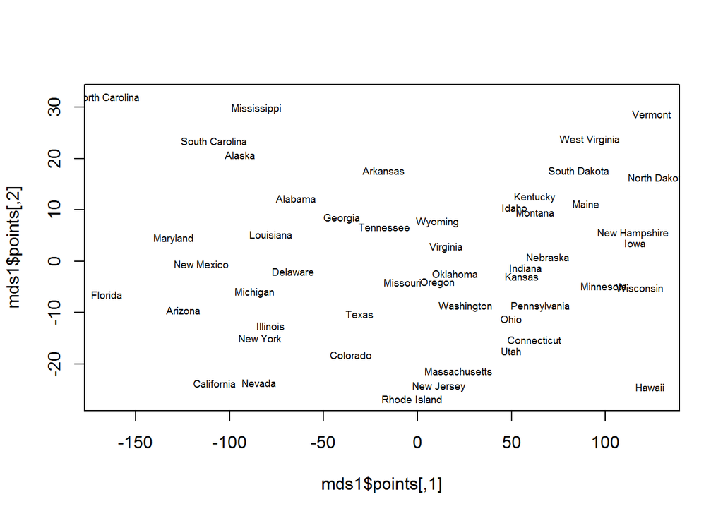

```r
plot(mds1$points, type = 'n')
text(mds1$points, rownames(mds1$points), cex = 0.6)
```

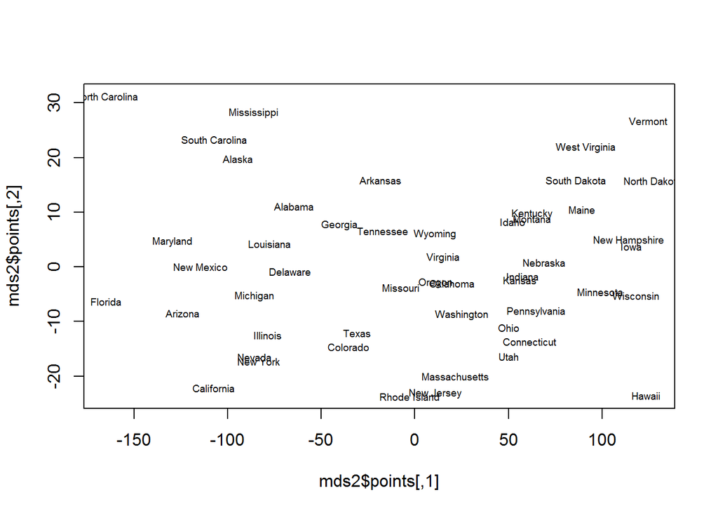

```r
plot(mds2$points, type = 'n')
text(mds2$points, rownames(mds2$points), cex = 0.6)
```

### Dane symulowane:

Macierz podobienstwa na macierzy 10000 wierszy x 200 kolumn.

```r
macierz10000x200 <- matrix(rnorm(2000000), ncol = 200)
system.time(macierz10000x200_dist <- dist(macierz10000x200))
```

```
##    user  system elapsed
##   99.56    0.21  100.82
```

Skalowanie metryczne:

```r
system.time(macierz10000x200_mds <- cmdscale(macierz10000x200_dist))
```

```
##    user  system elapsed
## 1267.44    2.79 1283.81
```

Podczas dzialania funkcji *cmdscale* zaalokowane bylo 3-4GB ramu.

Skalowanie niemetryczne:

```r
system.time(macierz10000x200_mds2 <- isoMDS(macierz10000x200_dist))
```

```
##    user  system elapsed
## 1550.09    6.41 1571.30
```

Dluzej niz skalowanie metryczne, ilosc zaalokowanej pamieci 3-4GB ramu.

```r
system.time(macierz10000x200_mds2 <- sammon(macierz10000x200_dist))
```

```
## Initial stress        : 0.81082
## stress after  10 iters: 0.77747, magic = 0.004
## stress after  17 iters: 0.74978
```

```
##    user  system elapsed
## 1251.50    3.15 1261.17
```